# Clustering

There is no shortage of ways to cluster data and the reasons to do it are just as numerous. Clustering is great for reducing the number of dimensions within your data (i.e., combining several variables into one), but it is equally well suited to finding natural groups within data.

## Centroid Clustering

Centroid clustering is based upon distances around some centroid (maybe a mean). Many centroid models tend to produce hard clustering by nature.

Careful attention needs to be paid to your data when clustering. Are they variables that naturally contain mean? If so, a k-means clustering might work well.

### Determining Cluster Numbers

As an example, let’s use the data from the Holzinger Swineford article, found in the lavaan package.

```r
library(factoextra)
library(lavaan)
library(dplyr)
testData = HolzingerSwineford1939 %>%
  dplyr::select(starts_with("x"))

kTest = NbClust::NbClust(testData, method = "kmeans")
```

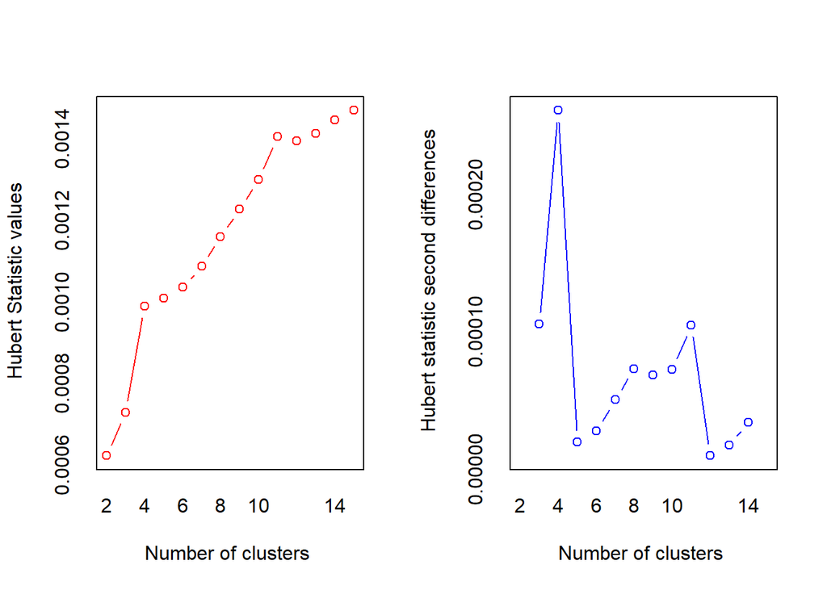

```
## *** : The Hubert index is a graphical method of determining the number of clusters.
##                 In the plot of Hubert index, we seek a significant knee that corresponds to a
##                 significant increase of the value of the measure i.e the significant peak in Hubert
##                 index second differences plot.
##
```

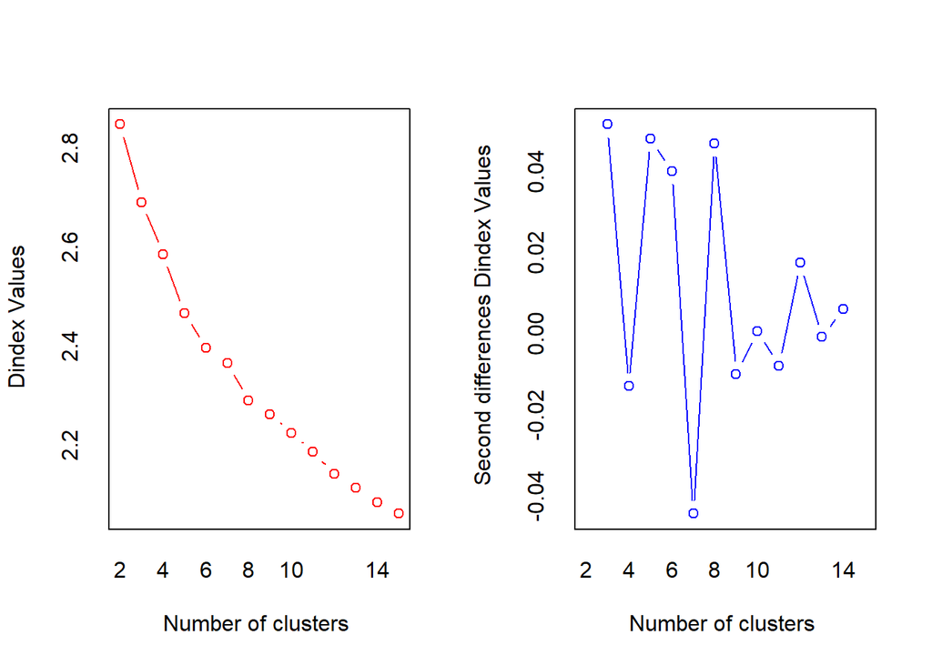

```
## *** : The D index is a graphical method of determining the number of clusters.
##                 In the plot of D index, we seek a significant knee (the significant peak in Dindex
##                 second differences plot) that corresponds to a significant increase of the value of
##                 the measure.
##
## * Among all indices:
## * 8 proposed 2 as the best number of clusters
## * 4 proposed 3 as the best number of clusters
## * 2 proposed 4 as the best number of clusters
## * 1 proposed 6 as the best number of clusters
## * 5 proposed 8 as the best number of clusters
## * 1 proposed 13 as the best number of clusters
## * 1 proposed 14 as the best number of clusters
## * 1 proposed 15 as the best number of clusters
##
##                    ***** Conclusion *****
##
## * According to the majority rule, the best number of clusters is  2
##
##
```

We are going to get a lot of information from the NbClust function, but a majority rule for number of clusters is the most helpful.

With our proposed number of clusters, let’s turn to some models.

### k-means

Let’s run a k-mean model with our test data.

```r
kmeansTest = kmeans(testData, 2)

kmeansTest
```

```
## K-means clustering with 2 clusters of sizes 129, 172
##
## Cluster means:
##         x1       x2       x3       x4       x5       x6       x7       x8
## 1 5.683463 6.565891 2.813953 3.894057 5.259690 2.973422 4.320863 5.743023
## 2 4.375000 5.729651 1.827762 2.436047 3.651163 1.594684 4.084681 5.365116
##         x9
## 1 5.785745
## 2 5.065407
##
## Clustering vector:
##   [1] 2 2 2 1 2 2 2 2 1 2 2 1 1 2 1 2 2 2 1 1 2 1 1 2 2 2 2 2 2 2 2 2 2 2 2
##  [36] 2 2 2 1 1 2 2 2 2 1 1 2 2 2 2 2 2 2 2 2 2 2 1 2 2 1 2 2 2 2 1 1 2 2 2
##  [71] 2 2 2 1 2 2 1 2 1 2 2 1 2 2 2 1 2 1 2 1 2 2 2 2 2 1 2 1 2 1 2 1 1 2 1
## [106] 1 1 1 1 2 1 1 1 1 2 2 1 2 2 2 2 2 1 2 1 1 1 1 1 2 1 1 2 2 1 1 1 1 1 1
## [141] 2 2 1 1 2 2 1 2 1 2 1 1 2 2 2 2 2 2 1 2 2 1 1 2 2 2 2 2 2 2 1 2 1 1 2
## [176] 1 2 1 1 1 2 1 1 2 2 2 2 2 2 2 2 1 1 2 2 1 1 1 2 2 1 1 2 2 2 1 2 2 2 2
## [211] 1 1 1 1 2 2 1 2 2 2 2 2 1 2 1 1 2 2 2 1 2 2 1 2 2 2 1 1 1 1 1 1 1 1 2
## [246] 1 1 1 1 2 1 1 1 1 1 1 1 1 1 2 1 2 2 1 1 1 1 1 1 2 1 1 2 2 2 2 2 1 2 1
## [281] 2 1 2 1 2 2 1 2 2 1 2 2 2 1 2 1 2 2 1 2 1
##
## Within cluster sum of squares by cluster:
## [1] 1169.721 1484.421
##  (between_SS / total_SS =  22.9 %)
##
## Available components:
##
## [1] "cluster"      "centers"      "totss"        "withinss"
## [5] "tot.withinss" "betweenss"    "size"         "iter"
## [9] "ifault"
```

Our output provides some very useful information. First, we see the cluster means for each item across the two cluster. These give us a pretty good idea of the “location” for each of the clusters and helps us to start to get an idea for what these cluster look like (we essentially have one higher scoring group and one lower scoring group).

Next, we see our clustering vector. This tells us to which cluster each observation was assigned.

We can also take a look at the bivariate plots, which will give us the cluster membershp within each of the bivariate plots.

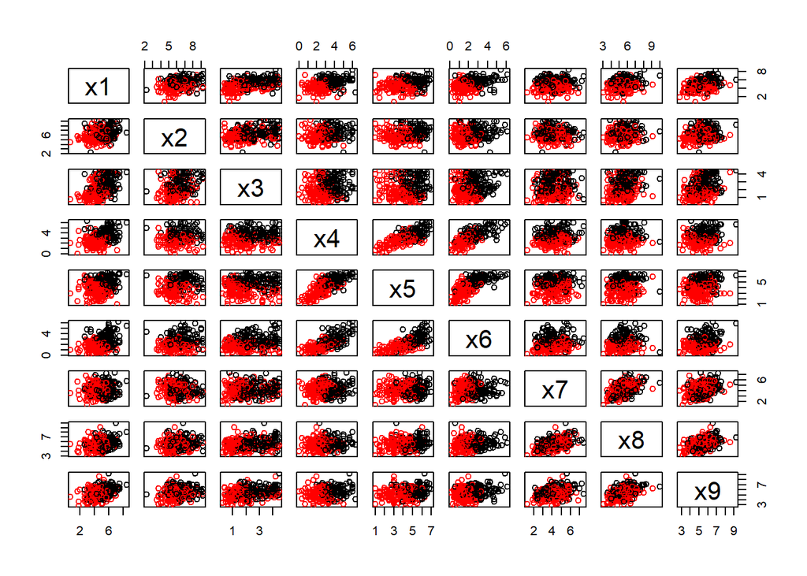

```r
plot(testData, col = kmeansTest$cluster)
```

We can see the variables were our clusters separate pretty nicely (e.g., x1 and x4) and were they do not (x8 and x9).

And a plot based upon the first two components of a PCA:

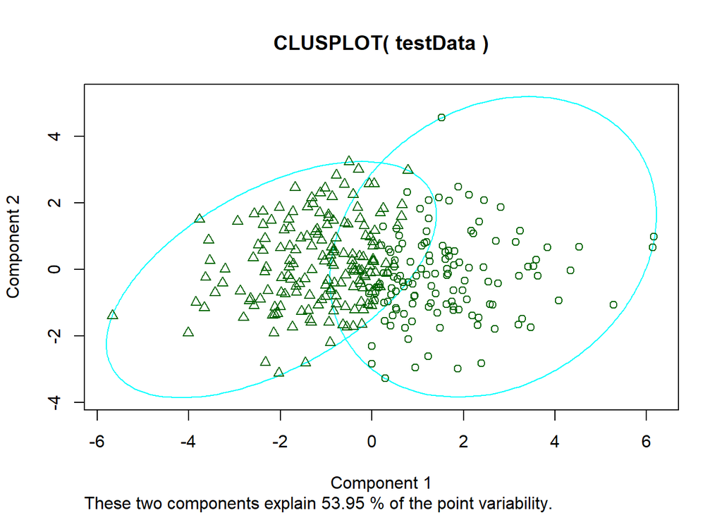

```r
cluster::clusplot(testData, kmeansTest$cluster)
```

The k-means cluster is great and widely used. But, it can be picky about data (it really likes data without extreme values) and it can have different results based upon item ordering (because of the cluster assignment process).

### medoids

To circumvent the issue within k-means, we can partition around medoids. Whereas our centroid can be an arbitrary value that gets observations clustered around it, a medoid is an actual observation within the data that then gets other observations clustered around it. In other words, the centroid does not relate to a specific observation, so the centroid cannot be linked to a specific observation.

```r
library(cluster)

pamTest = cluster::pam(testData, k = 2)

pamTest
```

```
## Medoids:
##       ID       x1   x2  x3       x4   x5       x6       x7   x8       x9
## [1,] 162 5.000000 6.25 2.5 3.333333 5.75 2.571429 4.086957 5.65 5.583333
## [2,]  11 3.666667 5.75 2.0 2.000000 3.50 1.571429 3.739130 5.70 4.305556
## Clustering vector:
##   [1] 1 2 2 1 2 2 1 2 1 2 2 1 1 1 1 2 2 2 1 1 2 1 1 2 2 2 2 2 1 2 2 2 1 1 2
##  [36] 2 1 2 1 1 2 2 2 2 1 1 2 2 2 1 2 1 2 2 1 1 2 1 2 2 1 1 2 1 2 1 1 2 2 1
##  [71] 2 2 2 1 2 2 1 2 1 2 2 1 2 2 2 1 1 1 2 1 2 2 2 2 1 1 1 1 2 1 1 1 1 1 1
## [106] 1 1 1 1 2 1 1 1 1 2 1 1 2 2 2 1 2 1 2 1 1 1 1 1 2 1 1 2 2 1 1 1 1 1 1
## [141] 1 2 1 1 2 1 1 2 1 1 1 1 1 2 2 1 2 1 1 2 1 1 1 1 1 1 2 2 1 2 1 2 1 1 1
## [176] 1 2 1 1 1 1 1 1 2 2 1 2 1 2 2 2 1 1 2 2 1 1 1 2 2 1 1 2 1 1 1 2 2 2 2
## [211] 1 1 1 1 2 1 1 2 1 2 2 2 1 2 1 1 1 1 2 1 2 1 1 2 2 1 1 1 1 1 1 1 1 1 1
## [246] 1 1 1 1 1 1 1 1 1 1 1 1 1 1 2 1 1 1 1 1 1 1 1 1 2 1 1 1 1 2 2 1 1 2 1
## [281] 2 1 2 1 2 1 1 2 1 1 1 2 1 1 1 1 2 2 1 1 1
## Objective function:
##    build     swap
## 3.159638 2.999334
##
## Available components:
##  [1] "medoids"    "id.med"     "clustering" "objective"  "isolation"
##  [6] "clusinfo"   "silinfo"    "diss"       "call"       "data"
```

We can see very similar output to what we got from k-means, but we get the actual observations that represent the medoids. This identification helps to us to get a better idea about what the clusters look like.

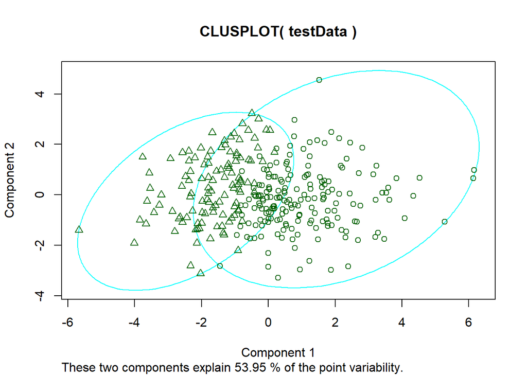

```r
cluster::clusplot(testData, pamTest$clustering)
```

If we look at both plots, we can notice some definite differences in cluster assignment when we are getting towards the 0s (pam puts some observations in one cluster, while kmean puts the same observation into a different cluster). This is purely a function of how the two methods compute the centroid.

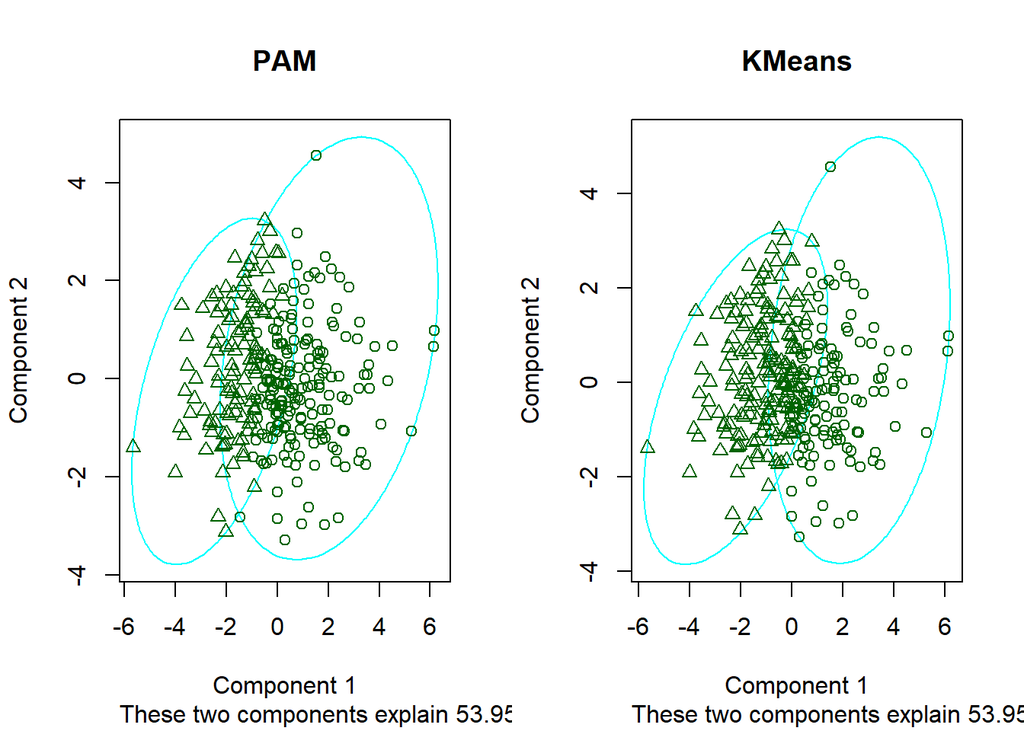

```r
par(mfrow = c(1, 2))

cluster::clusplot(testData, pamTest$clustering, main = "PAM")

cluster::clusplot(testData, kmeansTest$cluster, main = ("KMeans"))
```

## Distribution Clustering

Any centroid-based clustering algorithm works great when our data looks pretty normal. Data that might not be normally distributed might cause some issues in finding a decent centroid.

Imagine a variable distributed in the following manner:

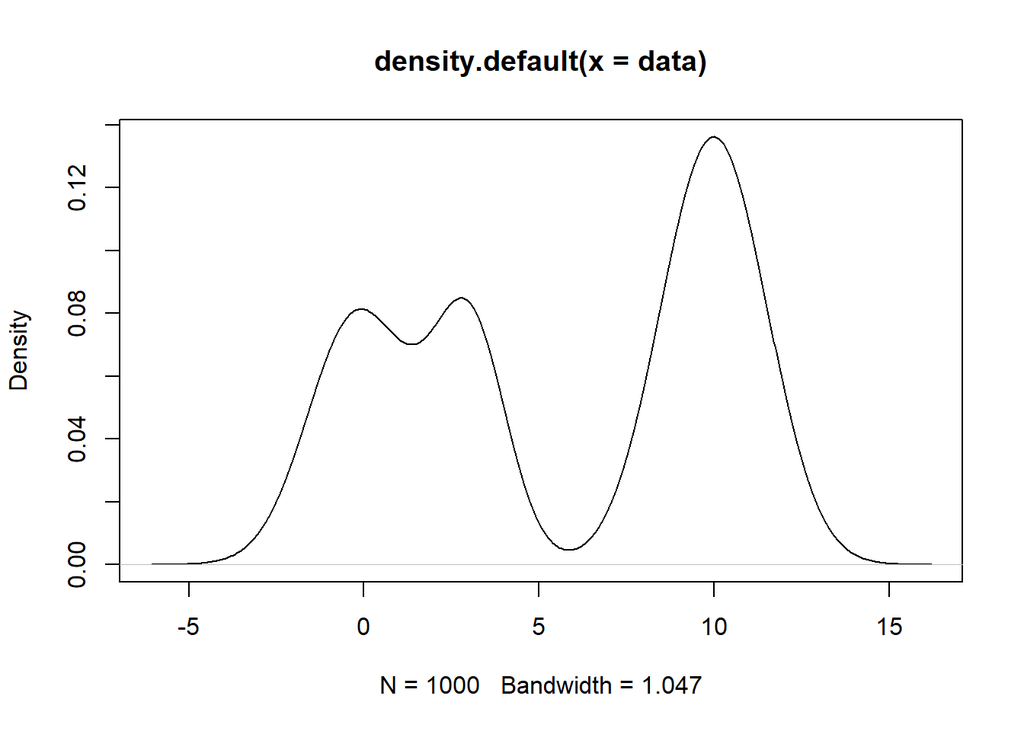

It looks like it has something close to a normal distribution on the right and something a bit lumpy on the left. Using a centroid-based algorithm would find a centroid, but we could almost imagine that this distribution is a mix of two different distributions – any centroid is going to betray the actual distribution of this data. Situations like this call for distribution clustering

Sometimes referred to as model-based clustering, distribution clustering allows us to model variables that have mixed distributions (maybe a mixture of normal distributions or a normal distribution and something like the bimodal-looking distribution we just saw).

If your data have a mixture of normals or you just want the actual distribution of your data to drive the clustering, then these distribution clustering algorithms will offer better solutions. Furthermore, they are better suited for clustering items that might have a latent structure.

Given that we are using our data’s distributions, we need to do another check on the number of clusters. Not only will we get a good number of clusters, but we will also get the clustering shapes that best fit our data.

```r
library(mclust)
bicTest = mclustBIC(testData)

bicTest
```

```
## Bayesian Information Criterion (BIC):
##         EII       VII       EEI       VEI       EVI       VVI       EEE
## 1 -8395.208 -8395.208 -8411.764 -8411.764 -8411.764 -8411.764 -7698.368
## 2 -8091.098 -8096.223 -8098.389 -8103.418 -8087.308 -8092.388 -7684.869
## 3 -8043.834 -8026.535 -7946.965 -7948.718 -7978.589 -7981.702 -7720.952
## 4 -7997.530 -7996.730 -7925.971 -7930.479 -7995.874 -8017.191 -7757.011
## 5 -7974.597 -7980.670 -7896.040 -7898.856 -7998.222 -8002.864 -7766.243
## 6 -7967.265 -7976.579 -7914.053 -7913.319 -8024.885 -8023.845 -7814.074
## 7 -7966.191 -7972.153 -7910.080 -7928.153 -8071.526 -8078.025 -7816.869
## 8 -7974.345 -8002.181 -7926.699 -7948.928 -8109.304 -8123.281 -7858.328
## 9 -8002.500 -8035.987 -7960.374 -7972.648 -8150.685 -8173.271 -7889.681
##         EVE       VEE       VVE       EEV       VEV       EVV       VVV
## 1 -7698.368 -7698.368 -7698.368 -7698.368 -7698.368 -7698.368 -7698.368
## 2 -7705.746 -7683.987 -7703.536 -7808.094 -7816.565 -7843.921 -7833.820
## 3 -7744.304 -7715.837 -7759.226 -7956.501 -7973.278 -8059.269 -8045.041
## 4 -7812.783 -7746.291 -7808.855 -8125.923 -8115.375 -8226.645 -8225.402
## 5 -7864.346 -7781.799 -7879.806 -8277.594 -8292.735 -8402.984 -8457.127
## 6 -7952.675 -7818.828 -7945.551 -8411.152 -8456.776 -8613.663 -8680.916
## 7 -7980.994 -7829.336 -7936.425 -8586.715 -8612.927 -8804.420 -8834.708
## 8 -8023.371 -7866.886 -8058.225 -8789.471 -8814.082 -9049.331 -9086.450
## 9 -8094.573 -7906.292 -8111.024 -8969.355 -9024.142 -9281.446 -9344.505
##
## Top 3 models based on the BIC criterion:
##     VEE,2     EEE,2     EEE,1
## -7683.987 -7684.869 -7698.368
```

Let’s take a peak at it:

```r
mclustTest = Mclust(testData, 2, modelNames = "VEE")

summary(mclustTest)
```

```
## ----------------------------------------------------
## Gaussian finite mixture model fitted by EM algorithm
## ----------------------------------------------------
##
## Mclust VEE (ellipsoidal, equal shape and orientation) model with 2
## components:
##
##  log.likelihood   n df       BIC       ICL
##       -3656.513 301 65 -7683.987 -7715.366
##
## Clustering table:
##   1   2
## 205  96
```

We can see that the provided output is very different than our previous clustering efforts. We have a cluster table, demonstrating how many observations are grouped into the two clusters. We also have mixing probabilites.

```r
mclustTest$parameters$pro
```

```
## [1] 0.6638782 0.3361218
```

The mixing probabilities add up to 1 and are just the probabilities that an observation will wind up in one cluster or another.

Now, let’s look at our clustering centers:

```r
mclustTest$parameters$mean
```

```
##        [,1]     [,2]
## x1 4.742245 5.318003
## x2 5.768518 6.719131
## x3 1.599823 3.535407
## x4 2.941652 3.296451
## x5 4.294729 4.430997
## x6 2.066251 2.421243
## x7 4.155177 4.246587
## x8 5.435710 5.707536
## x9 5.289581 5.541104
```

This is giving us an idea about the center for each of the clusters.

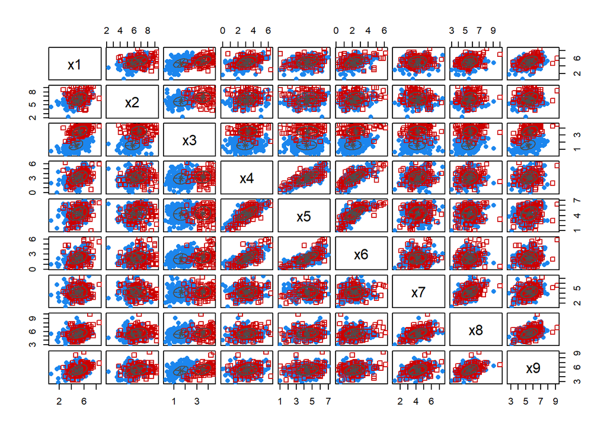

```r
plot(mclustTest, what = "classification")
```

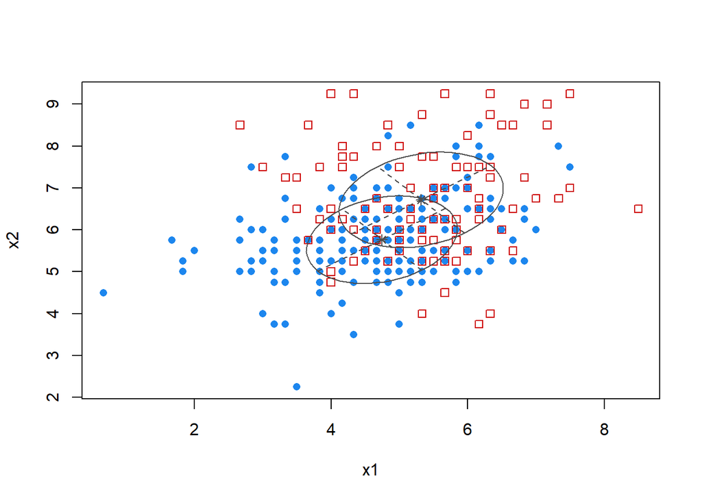

```r
coordProj(testData, parameters = mclustTest$parameters, z = mclustTest$z)
```

## Hierarchical Clustering

Everything we have seen to this point needs some type of work to know how many clusters to find.

Conversely, hiearchical clustering will cluster without any input. These hierarchical clustering approach can start with every observation as its own cluster and then start connecting those individual clusters into larger clusters. This continues until every cluster is clustered under a larger cluster. This process is known as agglomerative clustering (the reverse, where everything starts in one big cluster and is broken down into smaller clusters, is known as divisive clustering).

```r
hieararchicalTest = hclust(dist(testData))
```

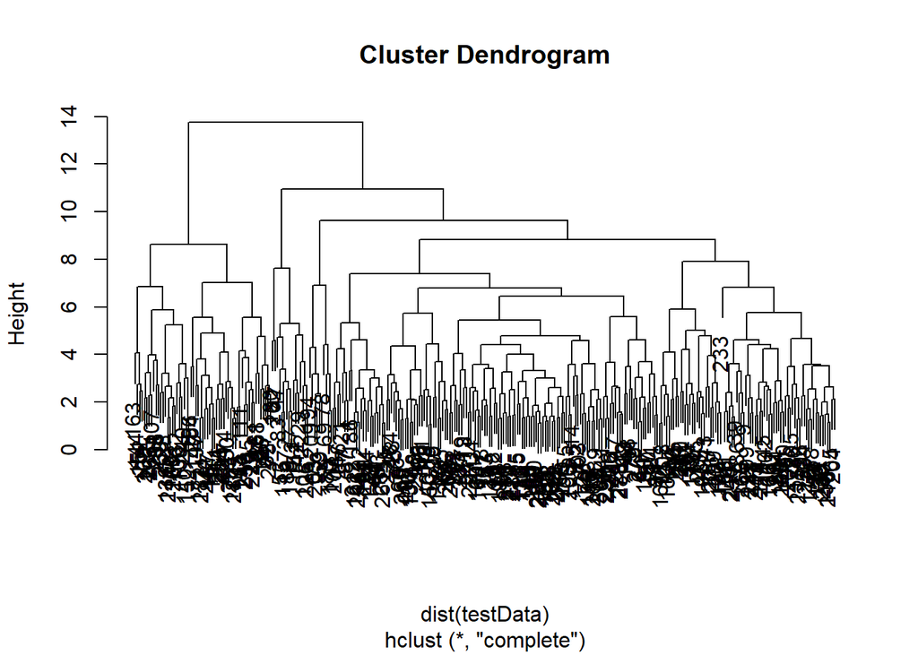

```r
plot(hieararchicalTest)
```

This monstrous-looking dendogram is showing us how the observations cluster all the way up the tree. The y-axis, Height, is telling us how similar observations are when they get clustered together – i.e., observations that are clustering at height 1 are much more similar than observations clustering at height 6.

If we want to get an idea about cluster membership, we need to determine where we want to cut our tree. For consistency with our other clustering algorithms, we can just go with defining two clusters:

```r
hier2Clus = cutree(hieararchicalTest, k = 2)
```

This provides the cluster membership so that we can identify the observations in our data that belong to a cluster:

```r
head(testData[hier2Clus == 2, ])
```

```
##          x1   x2    x3       x4   x5       x6       x7   x8       x9
## 15 5.833333 5.75 3.625 5.000000 5.50 3.000000 4.000000 4.35 5.861111
## 19 5.666667 5.25 4.000 4.333333 5.25 3.714286 3.913044 4.85 5.750000
## 20 6.333333 8.75 3.000 3.666667 3.75 2.571429 3.478261 5.35 4.916667
## 67 4.000000 9.25 4.000 3.000000 3.75 1.000000 3.608696 5.75 6.194444
## 74 5.000000 6.00 3.250 3.333333 5.75 2.714286 3.478261 4.60 4.277778
## 82 4.666667 8.00 4.250 3.000000 4.75 2.428571 5.130435 5.75 5.305556
```

Finally, we could get the averages for each variable for both clusters:

```r
rbind(cluster1 = testData[hier2Clus == 1, ] %>%
        summarize_all(mean),
      cluster2 = testData[hier2Clus == 2, ] %>%
        summarize_all(mean))
```

```
##                x1       x2       x3       x4       x5       x6       x7
## cluster1 4.722452 5.844008 2.042872 2.749311 4.047521 1.864227 4.120014
## cluster2 5.810734 7.088983 3.101695 4.338983 5.542373 3.503632 4.456153
##                x8       x9
## cluster1 5.421694 5.234848
## cluster2 5.959322 5.945386
```

Just like everything else we have seen, we have a lower scoring group and a higher scoring group.

## A Brief Word On Fuzzy Clustering

To this point, we have been using “hard” clustering – an observation is put into one cluster and there is no notion that the observation could belong to another. Fuzzy clustering changes this, by providing probabilities of class membership.

```r
fuzzyTest = fanny(testData, k = 2, memb.exp = 1.25)
```

We can get our clusters, just like we did with everything else:

```r
head(fuzzyTest$clustering)
```

```
## [1] 1 1 1 2 1 1
```

But a key difference is that we can also get the membership coefficients

```r
head(fuzzyTest$membership)
```

```
##           [,1]       [,2]
## [1,] 0.5830297 0.41697030
## [2,] 0.7306898 0.26931022
## [3,] 0.9219575 0.07804253
## [4,] 0.3316131 0.66838689
## [5,] 0.7620418 0.23795817
## [6,] 0.7734978 0.22650221
```

These can essentially be thought of as the probability of belonging to a cluster.

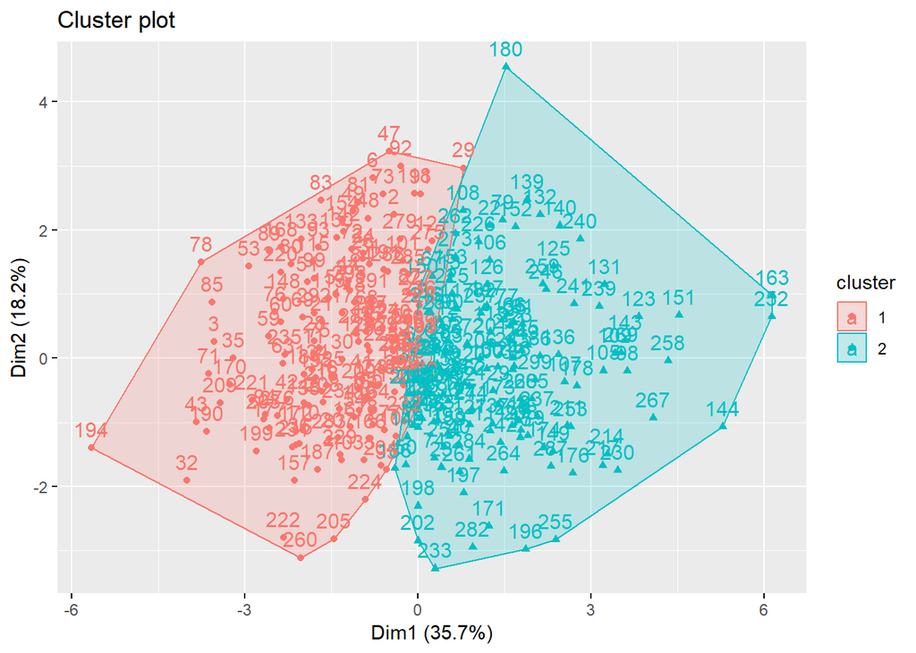

```r
fviz_cluster(fuzzyTest)
```

We can see that a great deal of the observations are pretty clear, but we can look at one of the observations that are resting between the 2 clusters.

```r
fuzzyTest$membership[67, ]
```

```
## [1] 0.4565806 0.5434194
```

We can see that it is not exactly 50/50, but it is pretty clear that this observation’s membership in cluster 2 is not 100% concrete.